# Discrete Time Processes: Information, Fair Games, and Convergence

## 1. Filtrations, adapted processes, and martingales

A filtration $(\mathcal F_n)_{n\in\mathbb N}$ records information as it accumulates, with $\mathcal F_n\subset\mathcal F_{n+1}$. A process $(M_n)_{n\in\mathbb N}$ is adapted when $M_n$ is $\mathcal F_n$-measurable. An adapted process with $M_n\in L^2(\Omega,\mathcal F_n,P)$ for every $n$ is a martingale when

$$ M_n=\mathbb E(M_{n+1}\mid\mathcal F_n), $$

and a submartingale when the equality is replaced by $M_n\leq\mathbb E(M_{n+1}\mid\mathcal F_n)$. The tree below uses the fair random walk $S_n=\sum_{j=1}^n X_j$, where $X_j=1$ for H and $X_j=-1$ for T.

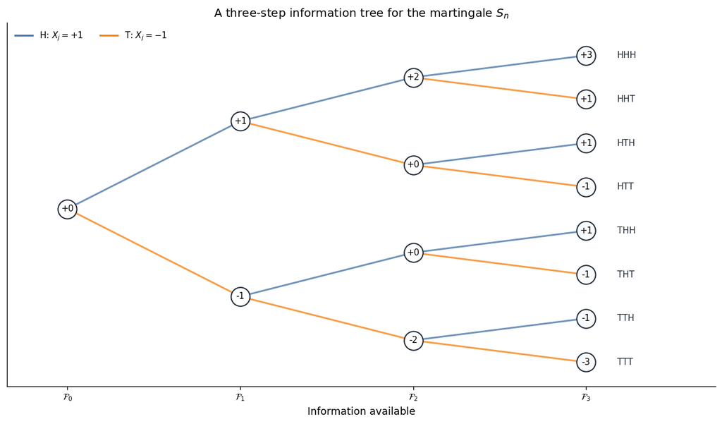

**Figure 1.** The filtration and values of the fair additive martingale $S_n$ over three coin tosses.

Interpretation. Moving from left to right reveals one additional increment. At every non-terminal node, the displayed value is the average of its two possible next values, so the tree gives a direct visual reading of $S_n=\mathbb E(S_{n+1}\mid\mathcal F_n)$.

## 2. Three canonical martingales

Chapter 2 gives three separate constructions:

$$ S_n=\sum_{j=1}^n X_j,\qquad P_n=\prod_{j=1}^n X_j,\qquad M_n=S_n^2-n\sigma^2. $$

The symbols describe different examples with different moment assumptions. The additive construction uses independent $X_j$ with $\mathbb E(X_j)=0$; the multiplicative construction uses independent $X_j$ with $\mathbb E(X_j)=1$; and the compensated-square construction uses independent $X_j$ with $\mathbb E(X_j)=0$ and $\mathbb E(X_j^2)=\sigma^2$. Definition 2.3 also requires each resulting process to be square-integrable; for the compensated-square example, finite fourth moments of the $X_j$ are a simple sufficient condition. The panels compare simulated paths with their ensemble means.

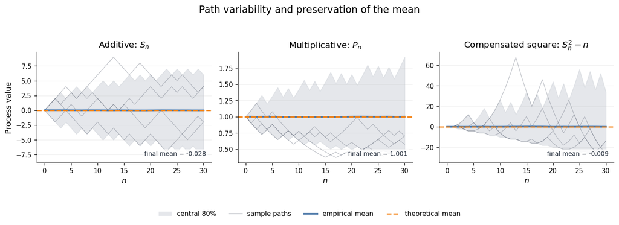

**Figure 2.** Simulated versions of the additive, multiplicative, and compensated-square martingales introduced in Chapter 2.

Interpretation. Individual paths spread out as information arrives, but the blue ensemble mean remains close to the orange reference level. The third panel also shows why the correction $n\sigma^2$ is needed: it removes the average quadratic growth of $S_n^2$.

## 3. Predictable strategies and martingale transforms

A process $(A_n)_{n\in\mathbb N}$ is predictable when $A_n$ is $\mathcal F_{n-1}$-measurable. If $(M_n)_{n\in\mathbb N}$ is a martingale and $\|A_n\|_\infty<\infty$ for every $n$, Theorem 2.10 states that

$$ \widetilde M_n=\sum_{j=1}^n A_j(M_j-M_{j-1}) $$

is also a martingale. The figure applies three bounded strategies to the same fair increments. The state-dependent stake is chosen from $S_{j-1}$, before the next increment is observed.

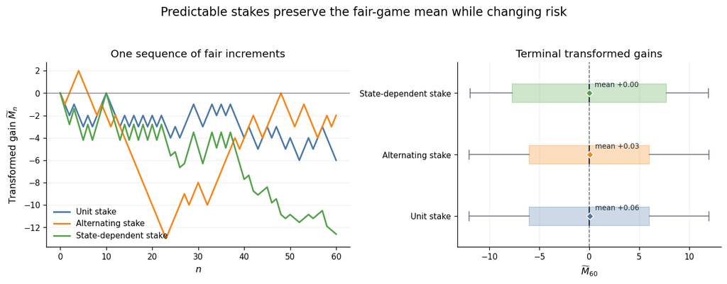

**Figure 3.** Three predictable transforms of the same fair random walk, with terminal distributions estimated from 15,000 paths.

Interpretation. The *unit stake* sets $A_j=1$ at every round; the *alternating stake* sets $A_j=1$ for odd $j$ and $A_j=-1$ for even $j$; and the *state-dependent stake* sets $A_j=1.4$ when $|S_{j-1}|<4$ and $A_j=0.35$ otherwise. The three rules produce different sample-path gains and terminal spreads while preserving a terminal mean near zero.

## 4. Stopping times and gambler's ruin

For positive integers $A$ and $B$, let

$$ \tau=\min\{n\in\mathbb N:S_n=A\ \text{or}\ S_n=-B\}, $$

where $\tau=\infty$ if neither boundary is ever reached. Then $(S_{n\wedge\tau})_{n\in\mathbb N}$ is the stopped martingale. In this fair random-walk setting, $\mathbb P(\tau<\infty)=1$, and Chapter 2 obtains

$$ \mathbb P(S_\tau=A)=\frac{B}{A+B},\qquad \mathbb E(\tau)=AB. $$

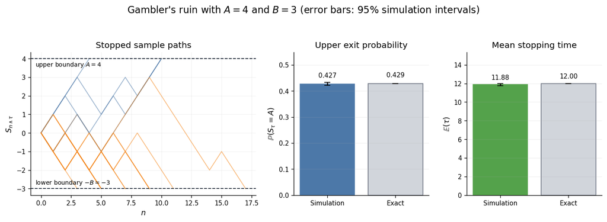

**Figure 4.** Stopped paths and simulation checks for gambler's ruin with $A=4$ and $B=3$; the error bars show 95% simulation intervals.

Interpretation. Each path remains at its first boundary once $\tau$ occurs. The two bar charts compare the simulated exit probability and mean stopping time with the exact values $B/(A+B)$ and $AB$. The numerical agreement is visible within the displayed simulation intervals; the formulas themselves quantify how the boundary distances $A$ and $B$ determine both quantities.

## 5. Maximal inequalities and convergence

For a non-negative submartingale $(M_n)_{n\in\mathbb N}$, define

$$ M_n^*=\max_{0\leq k\leq n}M_k. $$

Doob's maximal inequality gives, for $\alpha>0$,

$$ \alpha\,\mathbb P(M_n^*\geq\alpha) \leq \mathbb E\!\left(M_n\mathbf 1_{\{M_n^*\geq\alpha\}}\right) \leq \mathbb E(M_n). $$

The convergence theorem in Chapter 2 adds that $\sup_n\mathbb E(M_n^2)<\infty$ implies $M_n\to M_\infty$ almost surely and in $L^2$. The next section gives a concrete approximation sequence with this behaviour.

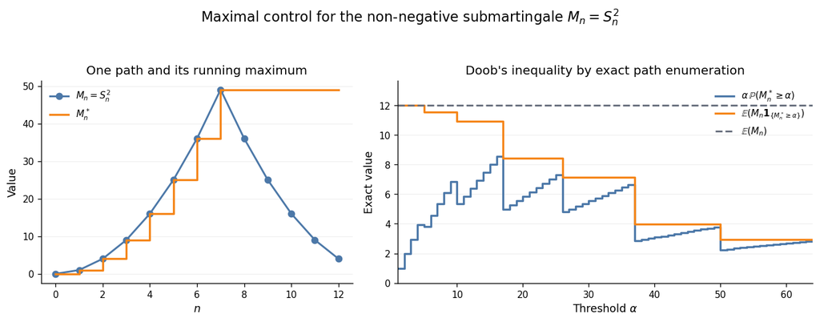

**Figure 5.** The maximal sequence for $M_n=S_n^2$ and the three quantities in Doob's maximal inequality at $n=12$.

Interpretation. The orange running maximum stays at its previous high when the blue process falls. In the right panel, exact enumeration of all $2^{12}$ paths places the blue curve below the orange curve and both below $\mathbb E(M_{12})=12$.

## 6. Dyadic martingales and the Haar basis

On $[0,1)$, let $\mathcal D_k$ be the partition into intervals $[i/2^k,(i+1)/2^k)$ for $i=0,\ldots,2^k-1$, and set $\mathcal F_k=\sigma(\mathcal D_k)$. For $f\in L^2([0,1))$,

$$ M_k(f)=\mathbb E(f\mid\mathcal F_k) $$

is the average of $f$ on the dyadic interval containing each point. As $k$ increases, $M_k(f)$ converges to $f$ almost surely and in $L^2$. The refinements are described by the Haar functions: if $H$ is $1$ on $[0,1/2)$, $-1$ on $[1/2,1)$, and zero elsewhere, then

$$ H_0(t)=1,\qquad H_{2^k+i}(t)=2^{k/2}H(2^kt-i),\qquad i=0,\ldots,2^k-1. $$

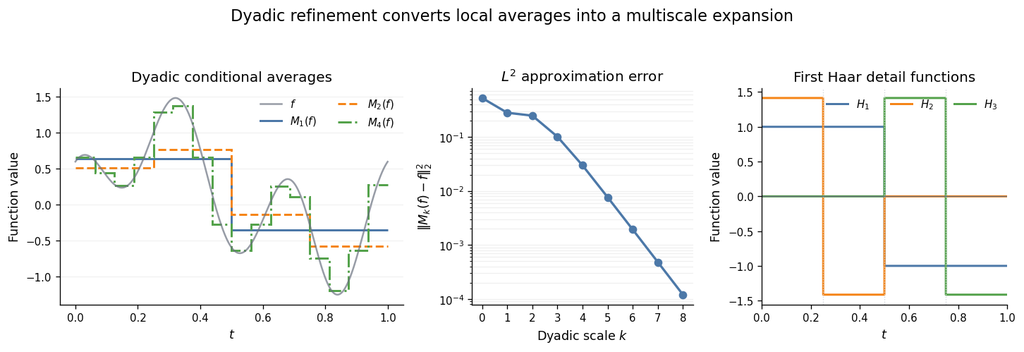

**Figure 6.** Dyadic conditional averages, their $L^2$ error, and the first Haar detail functions.

Interpretation. Finer dyadic information replaces broad block averages by increasingly local ones, while the middle panel records the resulting error decay. The Haar functions isolate the signed difference between neighbouring half-intervals, so each new scale adds local detail to the preceding approximation.